# Stillbirth, neonatal mortality and household WASH in Busoga

# Key findings

## Summary

# Data and populations

## From reports to analysis populations

| Step | Reports |
| --- | --- |
| Reports after merging first-visit and follow-up data | 32,003 |
| Excluded: no first-visit vital status | -23,951 |
| Excluded: contradictory status or dates | -34 |
| Births with a valid first-visit status (stillbirth analysis) | 8,018 |
| Excluded: alive at first visit, no 28-day follow-up | -3,092 |
| Births with a known stillbirth-or-death outcome | 4,926 |
| Excluded: stillbirths | -44 |
| Live births with a known 28-day outcome (NMR analysis) | 4,882 |

## Headline rates

| Measure | Events | Denominator | Rate per 1,000 (95% CI) |
| --- | --- | --- | --- |
| Stillbirth rate | 44 | 8,018 | 5.5 (95% CI 4.1–7.4) |
| Neonatal mortality rate (stillbirths excluded) | 104 | 4,882 | 21.3 (95% CI 17.6–25.7) |
| Stillbirth or death by day 28 (not an NMR) | 148 | 4,926 | 30.0 (95% CI 25.6–35.2) |

## Reading the headline rates

The stillbirth rate uses all births with a known first-visit status as the denominator. The NMR uses live births whose survival to day 28 is known. The third row shows why an earlier figure was misleading: pooling stillbirths with neonatal deaths gives a rate that is neither a stillbirth rate nor an NMR.

# Stillbirth

## Stillbirth rate by characteristic

```
`height` was translated to `width`.
```

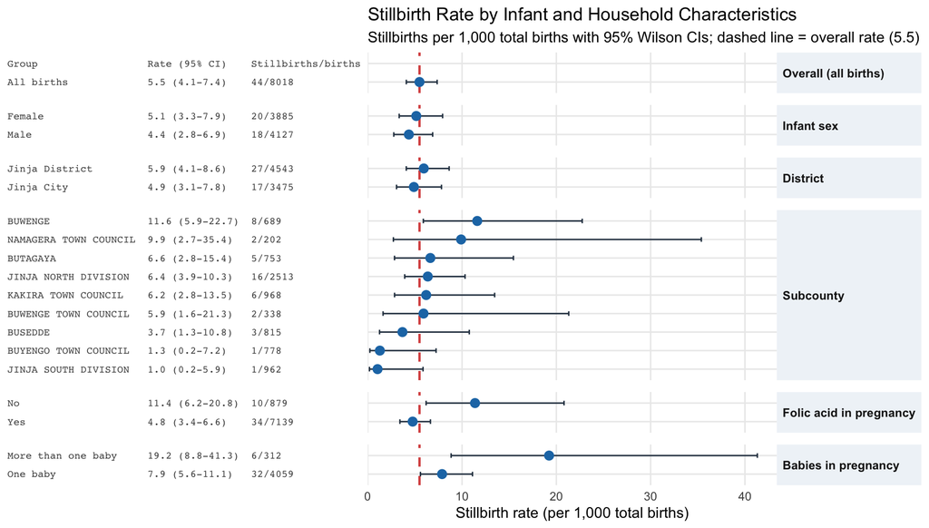

Figure 1

## Why stillbirth is not analysed by WASH

None of the stillbirths has WASH answers (0 of 44), so stillbirth is examined by the characteristics recorded for every report instead.

## Folic acid in pregnancy

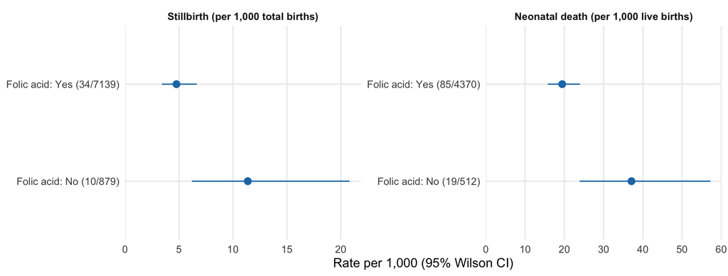

Figure 2

## Folic acid: what the data show

Women who did not take folic acid in pregnancy had more stillbirths (OR 2.49 (95% CI 1.18–4.81)) and more neonatal deaths (OR 1.98 (95% CI 1.17–3.20), Firth p = 0.013). The two associations point the same way, which makes a chance finding somewhat less likely, but folic acid use may mark access to antenatal care or wealth and this comparison is not adjusted for either.

## More than one baby, and geography

Pregnancies with more than one baby had a higher stillbirth rate: 19.2 per 1,000 (6/312) vs. 7.9 per 1,000 (32/4059) (OR 2.63 (95% CI 1.02–5.77)). The question was blank for 3,647 births (the reason is not established), so this comparison rests on far fewer births than the others.

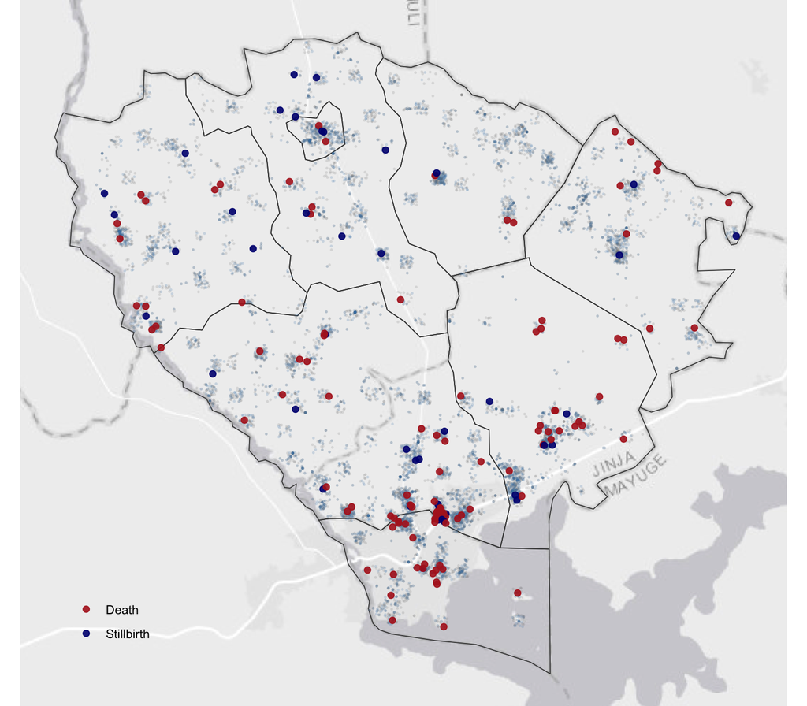

Figure 3: Stillbirths and deaths against all births, Busoga. Most locations are approximate.

# Neonatal mortality and WASH

## NMR by WASH exposure

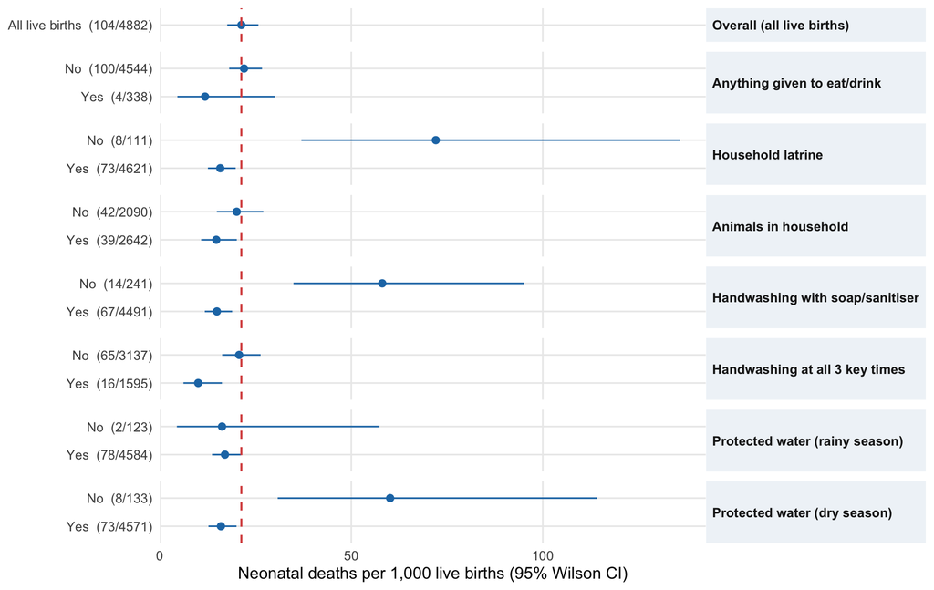

Figure 4

## Reading the NMR plot

The dashed line is the overall NMR (21.3 per 1,000). Groups without a latrine, without soap or sanitiser, and with unprotected dry-season water sit well above it, but they are small groups with wide intervals.

## Odds ratios (Firth)

```
`height` was translated to `width`.
```

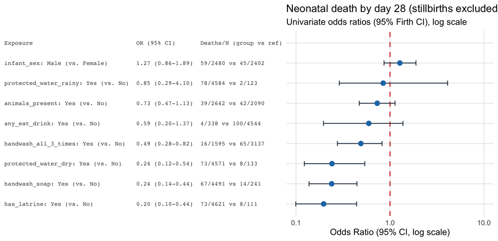

Figure 5

## Sanitation and handwashing

Odds of neonatal death were lower where:

- the household had a latrine: OR 0.20 (95% CI 0.10–0.44), based on only 111 births without a latrine;
- soap or sanitiser was used for handwashing: OR 0.24 (95% CI 0.14–0.44);
- handwashing happened at all three key times: OR 0.49 (95% CI 0.28–0.82);
- handwashing before feeding the baby was reported: OR 0.37 (95% CI 0.22–0.61).

Handwashing with water only had higher odds than soap (OR 4.17 (95% CI 2.24–7.25)). Animals in the household and infant sex showed no clear association.

# Water source

```
`height` was translated to `width`.
```

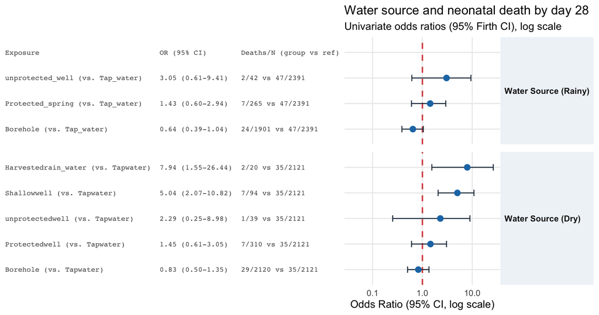

Figure 6

## What the dry-season result says

Grouped as protected versus unprotected sources, protected dry-season water had OR 0.24 (95% CI 0.12–0.54). The “unprotected” group is mostly shallow wells (94 of 133 infants), so that binary result largely reflects shallow wells (60.2 per 1,000 (8/133) in the unprotected group).

The rainy-season sources showed no clear differences, and two rainy-season groups had no deaths (shallow well and harvested rainwater), so they cannot be compared. The harvested-rainwater result in the dry season rests on only 2 deaths among 20 infants.

# Comparing the two outcomes

## Stillbirth-or-death vs. neonatal death

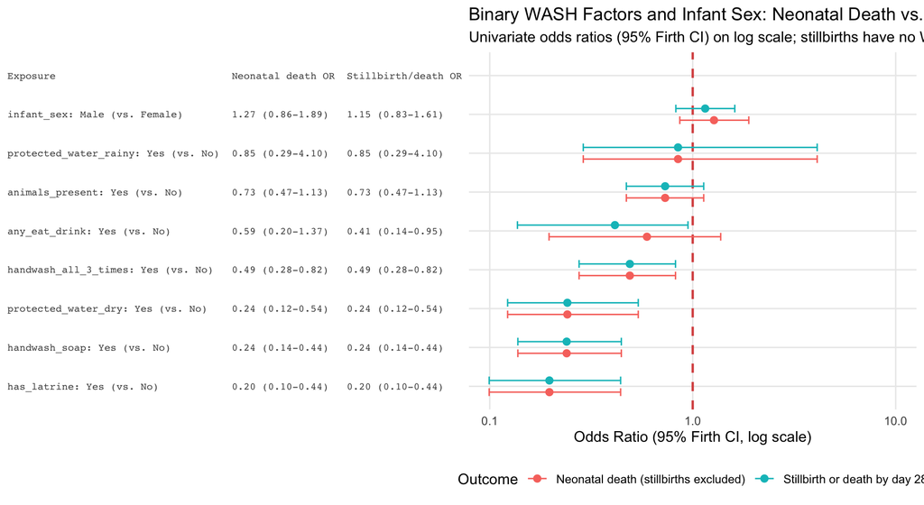

Figure 7

## What changes when stillbirths are removed

| Exposure | Neonatal death OR (95% CI) | Neonatal death p | Stillbirth or death OR (95% CI) | Stillbirth or death p |
| --- | --- | --- | --- | --- |
| any_eat_drink: Yes (vs. No) | 0.59 (0.20-1.37) | 0.25 | 0.41 (0.14-0.95) | 0.035 |
| Milk (Non-breast) (vs. None / Blank) | 0.35 (0.04-1.29) | 0.13 | 0.24 (0.03-0.89) | 0.029 |
| Other Item (vs. None / Blank) | 2.40 (0.65-6.24) | 0.16 | 1.67 (0.46-4.31) | 0.390 |
| BCG (vs. None / Blank) | 1.03 (0.01-7.53) | 0.98 | 0.72 (0.01-5.21) | 0.810 |
| Breastmilk (vs. None / Blank) | 0.36 (0.00-2.52) | 0.39 | 0.25 (0.00-1.75) | 0.210 |
| infant_sex: Male (vs. Female) | 1.27 (0.86-1.89) | 0.22 | 1.15 (0.83-1.61) | 0.410 |

## Why the two outcomes differ

Every WASH comparison is identical under the two outcomes except those involving what the infant was given to eat or drink, because stillbirths have no WASH answers except this one, which was recoded to “none” when blank. The apparent protective effect of “anything given to eat or drink” weakens once stillbirths are removed, which suggests it was largely an artefact of the blank-means-none coding for infants who were stillborn. The remaining WASH associations (latrine, soap, handwashing, dry-season water) are unaffected.

Infant sex also moves slightly, from 1.15 (0.83-1.61) to 1.27 (0.86-1.89) for male vs. female, simply because the 44 stillbirths are no longer counted. Neither interval excludes 1.

# Caveats

## Interpreting these results

- **Missing WASH answers:** only 81 of 104 neonatal deaths have a latrine answer, so the remaining deaths cannot contribute to the WASH comparisons.
- **Follow-up:** 3,092 infants alive at the first visit have no 28-day follow-up and are excluded from the NMR. If their survival differs from those followed up, the NMR is biased.
- **First-visit status:** 23,951 of the 32,003 reports have no first-visit vital status and were excluded. The reason is not established in the data.
- **Small groups and sparse cells:** many exposure groups have fewer than 100 infants and a handful of deaths. Firth regression stabilises the estimates, but the intervals are wide.
- **Unadjusted and uncorrected:** each association is univariate, about 30 comparisons were made without correction for multiple testing, and confounding by wealth, antenatal care or place of birth is possible.
- **Blank answers:** folic acid was blank for 0 births and the plurality question for 3,647; blanks are excluded from those comparisons.

# Appendix: full grouped odds-ratio plots

## Neonatal death by WASH domain

```
`height` was translated to `width`.
```

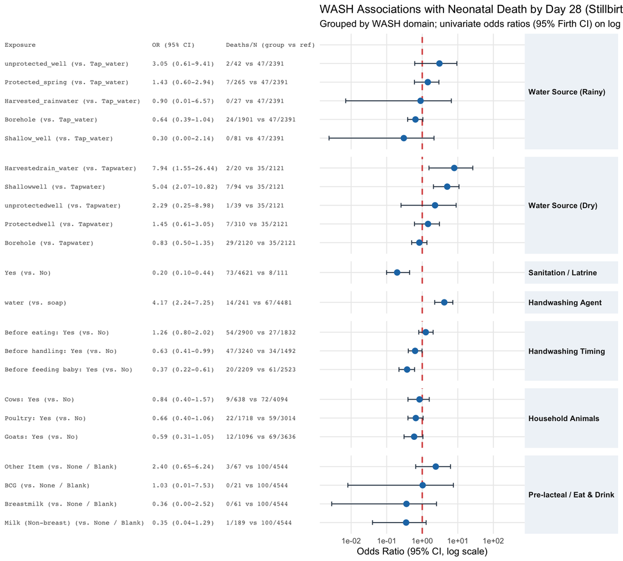

Figure 8

## Stillbirth-or-death vs. neonatal death by WASH domain

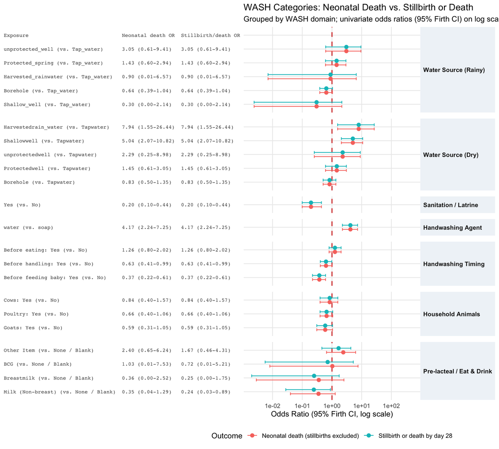

Figure 9

## Stillbirth Firth odds ratios

| Characteristic | Level | Reference | OR (95% CI) | p |
| --- | --- | --- | --- | --- |
| Infant sex | Female | Male | 1.18 (0.63–2.23) | 0.610 |
| District | Jinja City | Jinja District | 0.83 (0.45–1.50) | 0.540 |
| Subcounty | BUSEDDE | JINJA NORTH DIVISION | 0.65 (0.17–1.85) | 0.450 |
| Subcounty | BUTAGAYA | JINJA NORTH DIVISION | 1.11 (0.38–2.76) | 0.830 |
| Subcounty | BUWENGE | JINJA NORTH DIVISION | 1.89 (0.78–4.23) | 0.150 |
| Subcounty | BUWENGE TOWN COUNCIL | JINJA NORTH DIVISION | 1.12 (0.22–3.62) | 0.870 |
| Subcounty | BUYENGO TOWN COUNCIL | JINJA NORTH DIVISION | 0.29 (0.03–1.17) | 0.088 |
| Subcounty | JINJA SOUTH DIVISION | JINJA NORTH DIVISION | 0.24 (0.03–0.94) | 0.039 |
| Subcounty | KAKIRA TOWN COUNCIL | JINJA NORTH DIVISION | 1.02 (0.38–2.43) | 0.960 |
| Subcounty | NAMAGERA TOWN COUNCIL | JINJA NORTH DIVISION | 1.89 (0.37–6.10) | 0.390 |
| Folic acid in pregnancy | No | Yes | 2.49 (1.18–4.81) | 0.018 |
| Babies in pregnancy | More than one baby | One baby | 2.63 (1.02–5.77) | 0.045 |

# Methods

## Data sources

Data come from two ODK Central forms for the CONRIM surveillance project in Busoga, Uganda, downloaded to `JinjaFiles/`: the short form completed at the first visit (32,695 rows) and the 28-day follow-up form (4,925 rows). Each form was reduced to one row per participant (first visit: the earliest report with a known vital status; follow-up: the latest contact with a known vital status) and the two were joined by participant number.

## Inclusion

Reports with no first-visit vital status (23,951) were excluded. A further 34 reports were excluded because the vital status contradicted itself (dead at the first visit but alive at follow-up) or the date of death was before the date of birth or the survey. The remaining 8,018 births form the stillbirth population.

## Outcome definitions

- **Stillbirth:** an infant recorded as dead at the first visit with cause of death “Stillbirth”.
- **Neonatal death:** a live birth that died by day 28. Age at death comes from the dates of birth and death. Deaths without a recorded date were counted as neonatal if reported at the first visit or at follow-up within 28 days. Deaths after day 28 and infants confirmed alive at follow-up were counted as survivors.
- **Unknown outcome:** infants alive at the first visit with no follow-up. They count as births for the stillbirth rate but are excluded from the NMR.
- **Rates:** the stillbirth rate is stillbirths per 1,000 total births (live births plus stillbirths). The NMR is neonatal deaths per 1,000 live births with a known 28-day outcome. Both are crude, unadjusted rates.

## Exposures

Household WASH questions were recoded into yes/no variables: latrine; anything given to eat or drink (any item versus blank, with blank treated as none); animals in the household; soap or sanitiser used for handwashing; handwashing at all three key times (before eating, before handling and before feeding the baby); and protected water source in the rainy and dry seasons. Protected sources were borehole, tap water, protected spring, protected well and harvested rainwater (an assumption based on the WHO/UNICEF JMP “improved” definition); shallow well and unprotected well were unprotected. Detailed category versions of the water, handwashing, eating and drinking, animal and handwashing-timing variables were also analysed. Stillbirth was additionally examined by infant sex, district, subcounty, folic acid use in pregnancy and number of babies in the pregnancy (the variable `introduction_hh_twins`).

## Reproducibility

The analyses are produced by `scripts/Load_data.R` (loading, cleaning, outcomes, exposures), `scripts/forest_helpers.R` (shared model-fitting and plotting functions), `Forest_stillbirth.R`, `Forest_NMR.R` and `Forest_OR_firth.R` (also in `scripts/`), which this report runs. Software: R version 4.5.1 (2025-06-13), `logistf` 1.26.1, `ggplot2` 4.0.3, `dplyr` 1.2.1.